# withjustone

We can have a look at the them first:

```r
rm(list=ls())
library('mash')
set.seed(123)
c=chat_sim_fsingle_fixedomega(n = 10000,d = 8,omega = 2,esd = 0.1)
saveRDS(c,"chatfixedomega.rds")
diag(c$covmat)
```

```
## [1] 0 0 0 0 0 0 1 1
```

And here we run our analysis:

```r
t=c$t;b=c$chat;se=c$shat
#hist(t)
#hist(b)
R=ncol(t)
L=diag(R)-1/R*as.vector(rep(1,R))%*%t(as.vector(rep(1,R)))
s.j=se/se

absmat=abs(t(L%*%t(c$t)))
index=which(rowSums(absmat>4)>0)
length(index)
```

```
## [1] 748
```

```r
mean(index<1000)
```

```
## [1] 0.9986631
```

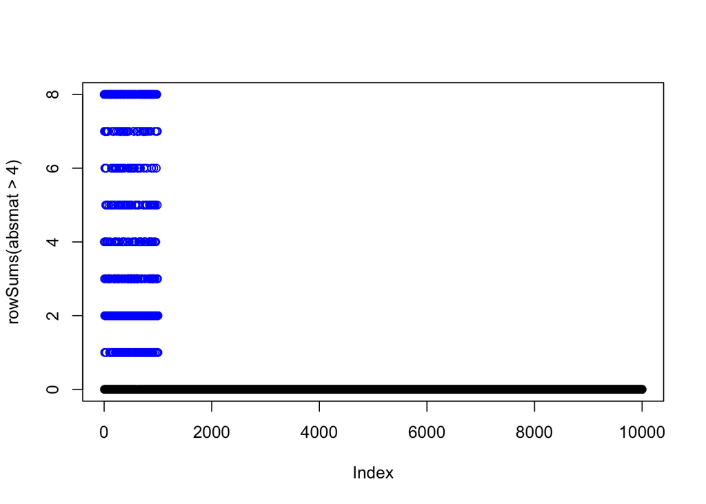

```r
#index=which(rowMeans(abs(t(L%*%t(c$t))))>1.3)##choose the associations with average deviation large.

##show deviations
plot(rowSums(absmat>4))
points(index,rowSums(absmat>4)[index],col="blue")
```

```r
sparsestrongt=t(L%*%t(t[index,]))
```

```r
write.table(sparsestrongt,"sparsestrongt.txt",col.names = FALSE,row.names=FALSE)
```

Now, we need to project into the centered space to estimate the covariance matrix of the true deviations, using the full L since $v$ will be R, and not $R-1$.

```r
system('/Users/sarahurbut/miniconda3/bin/sfa -gen sparsestrongt.txt -g 748 -k 5 -n 8 i -o sparseF')
A="sparseF"

factor.mat=as.matrix(read.table("sparseF_F.out"))
lambda.mat=as.matrix(read.table("sparseF_lambda.out"))

#recall here that w will now be the L[-1,]%*%t(t[strong,]), which is equivalent to removing the first column of the strong projected t. Thus the covariance of v is initated with the RxR matrices (strong projected t), and the model is trained on the strong projected t less the first column because the model has v_{rxr}|w_{r,r-1}

strongprojectedt=sparsestrongt


lvllist=genlvllist(s.j[index,],L = L[-1,])


##w should represent transformed betahats using all R subgroups and j genes
wfull=t(L%*%t(b))
sjmat=convertstandarderrors(s.j = se,L=L)##make this be the standard errors of all, it is the sqrt of the diagonal of LVL' for each j. Recall here L is still RxR so we can have the full set of deviations and thier standard errors to choose grid
dim(wfull)
```

```
## [1] 10000     8
```

```r
dim(sjmat)
```

```
## [1] 10000     8
```

```r
w=data.frame(wfull)[,-1]
```

Now run with ED to show that 1) the likelihood improves 2) we have successfully implemented an approach which allows us to input a list of residual variance matrices (as opposed to a matrix of vectors to be diagonalised). 3) Let’s just do it with one covariance matrix from ED

```r
source("~/matrix_ash/R/mashnobasescripts.R")
source("~/matrix_ash/R/truthscripts.R")
rm(A)

A="withoneK"


library("ExtremeDeconvolution")
efunc=deconvolution.em.with.bovy.with.L.oneK(t.stat = strongprojectedt,v.j = lvllist,L = L[-1,],w = strongprojectedt[,-1])

dim(efunc$true.covs)
```

```
## [1] 1 8 8
```

```r
length(efunc$pi)
```

```
## [1] 1
```

```r
efunc$true.covs[1,,]-min(abs(efunc$true.covs[1,,]))
```

```
##              [,1]         [,2]        [,3]        [,4]        [,5]
## [1,]   0.09289778   0.00000000   0.2223919   0.3761126   0.2474769
## [2,]   0.00000000   0.04069422   0.2095228   0.3667614   0.2540590
## [3,]   0.22239194   0.20952281   0.4638664   0.5953335   0.4570061
## [4,]   0.37611259   0.36676141   0.5953335   0.7986600   0.6096197
## [5,]   0.24747692   0.25405900   0.4570061   0.6096197   0.5192982
## [6,]   0.17786780   0.16284927   0.4180805   0.5733402   0.4037604
## [7,] -64.35327711 -64.25240611 -64.9326697 -65.3987478 -64.9739890
## [8,] -64.16400615 -64.18201682 -64.8340679 -65.3216159 -64.9177675
##             [,6]      [,7]      [,8]
## [1,]   0.1778678 -64.35328 -64.16401
## [2,]   0.1628493 -64.25241 -64.18202
## [3,]   0.4180805 -64.93267 -64.83407
## [4,]   0.5733402 -65.39875 -65.32162
## [5,]   0.4037604 -64.97399 -64.91777
## [6,]   0.4142372 -64.84654 -64.70413
## [7,] -64.8465377 130.92009 130.43700
## [8,] -64.7041339 130.43700 130.28607
```

```r
##compare to initialized matrix
X.real=as.matrix(strongprojectedt)
X.c=apply(X.real,2,function(x) x-mean(x)) ##Column centered matrix of t statistics
data.prox=((t(X.c)%*%X.c))/(nrow(X.real)-1)
(data.prox)-min(abs(data.prox))
```

```
##             [,1]        [,2]        [,3]        [,4]        [,5]
## [1,]   1.0854520   0.0000000   0.2577479   0.4021358   0.2753768
## [2,]   0.0000000   1.0202116   0.2200933   0.3632262   0.2753067
## [3,]   0.2577479   0.2200933   1.4275848   0.5814482   0.4738139
## [4,]   0.4021358   0.3632262   0.5814482   1.7646172   0.6052257
## [5,]   0.2753768   0.2753067   0.4738139   0.6052257   1.5049885
## [6,]   0.1577889   0.1552241   0.4792932   0.6059439   0.4199799
## [7,] -64.4016456 -64.2618951 -64.9592606 -65.3924599 -65.0007085
## [8,] -64.1805692 -64.1758804 -64.8844341 -65.3338505 -64.9576965
##             [,6]      [,7]      [,8]
## [1,]   0.1577889 -64.40165 -64.18057
## [2,]   0.1552241 -64.26190 -64.17588
## [3,]   0.4792932 -64.95926 -64.88443
## [4,]   0.6059439 -65.39246 -65.33385
## [5,]   0.4199799 -65.00071 -64.95770
## [6,]   1.3610390 -64.88537 -64.69761
## [7,] -64.8853701 131.99124 130.50639
## [8,] -64.6976124 130.50639 131.31994
```

Now let’s create a list of covariance matrices just as we do with the truth comparions, containing the identity, the one matrix, and zero:

```r
covlist=list();covlist[[1]]=efunc$true.covs[1,,]
edcov=compute.covmat.using.oneK.fixed.omega(covlist = covlist,A = A,omega = 2,zero = TRUE)

length(edcov)
```

```
## [1] 3
```

```r
sapply(edcov,function(x){max(diag(x))})
```

```
## [1] 2 2 0
```

```r
all.equal(edcov[[2]]/max(diag(edcov[[2]])),efunc$true.covs[1,,]/max(diag(efunc$true.covs[1,,])))
```

```
## [1] TRUE
```

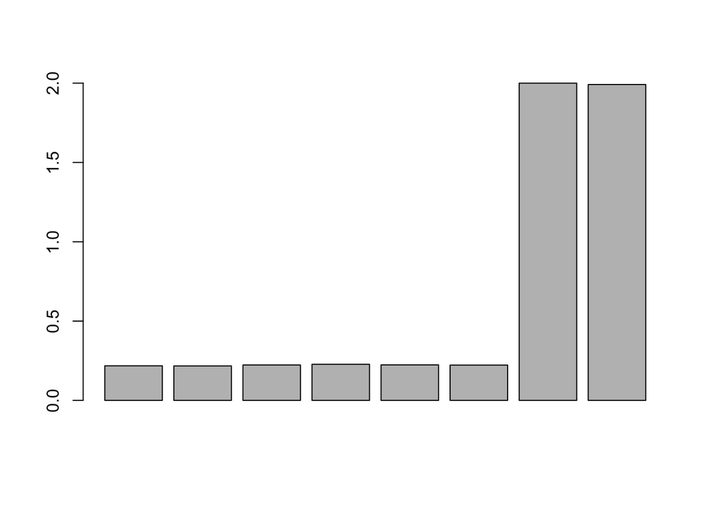

```r
barplot(diag(edcov[[2]]))
```

Now let’s compute the likelihood with ED:

```r
w=data.frame(wfull)[,-1]

compute.hm.train.log.lik.pen.with.L(w,se.train = se,covmat = edcov,A = A,pen = 1,L = L[-1,])
```

```r
pis=readRDS(paste0("pis",A,".rds"))$pihat

likmat=readRDS(paste0("liketrain",A,".rds"))
test=exp(likmat)
sum(log(test%*%pis))
```

```
## [1] 66493.43
```

```r
for(j in 1:nrow(w)){
total.quant.per.snp.no.baseline(j = j,covmat = edcov,b.gp.hat = w,se.gp.hat = se,pis = pis,A = A,checkpoint = F,L = L[-1,])}
```

## Test to show our calculations are accurate:

```r
mash.means=as.matrix(read.table("withoneKposterior.means.txt")[,-1])
lfsr.mash=as.matrix(read.table("withoneKlfsr.txt"))[,-1]
edcov=readRDS("covmatwithoneK.rds")
j=10
arrays=post.array.per.snp.no.baseline(j = 10,covmat = edcov,b.gp.hat = w,se.gp.hat = se,L = L[-1,])
k=2

V.gp.hat=diag(se[j,])^2

b.mle = as.vector(w[j,])

LSigL=L[-1,]%*%edcov[[k]]%*%t(L[-1,])
LVL=L[-1,]%*%V.gp.hat%*%t(L[-1,])

LSigL_list=lapply(edcov,function(x){L[-1,]%*%x%*%t(L[-1,])})
identical(LSigL_list[[k]],LSigL)
```

```
## [1] TRUE
```

```r
identical(as.numeric(arrays$post.means[k,]),as.numeric(post.mean.with.proj(b.mle = t(b.mle),tinv = solve(LVL+L[-1,]%*%edcov[[k]]%*%t(L[-1,])),U.k = edcov[[k]],L = L[-1,])))
```

```
## [1] TRUE
```

```r
identical(as.numeric(arrays$post.covs[k,]),as.numeric(diag(post.cov.with.proj(tinv = solve(LVL+L[-1,]%*%edcov[[k]]%*%t(L[-1,])),U.k = edcov[[k]],L = L[-1,]))))
```

```
## [1] TRUE
```

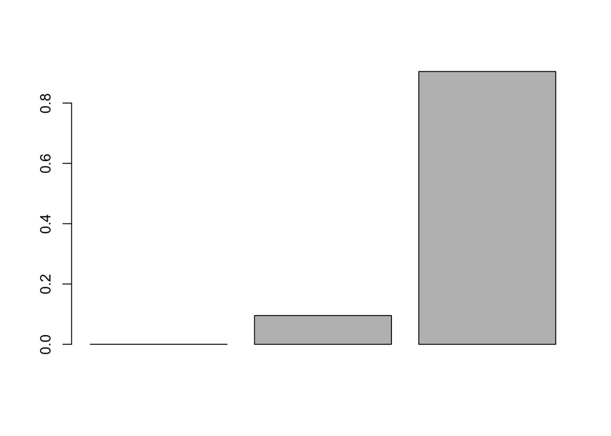

```r
log.lik.snp=log.lik.func(b.mle,LVL,LSigL_list)
log.lik.minus.max=log.lik.snp-max(log.lik.snp)
pis=readRDS("piswithoneK.rds")$pihat
barplot(pis)
```

```r
exp.vec=exp(log.lik.minus.max)
post.weights=t(exp.vec*pis/sum(exp.vec*pis))

all.equal(as.numeric(post.weights%*%arrays$post.means),as.numeric(mash.means[j,]))
```

```
## [1] TRUE
```

Let’s compare with truth:

## Comparing with truth.

Now, let’s try this with the true prior. Here, we use the covariance matrices that were used to simulate the data as the output of *c$covmat*

```r
rm(list=ls())
library('mash')

c=readRDS("chatfixedomega.rds")
diag(c$covmat)
```

```
## [1] 0 0 0 0 0 0 1 1
```

```r
t=c$t;b=c$chat;se=c$shat
covl=list();covl[[1]]=c$covmat
#hist(t)
#hist(b)
R=ncol(t)
L=diag(R)-1/R*as.vector(rep(1,R))%*%t(as.vector(rep(1,R)))
wfull=t(L%*%t(b))
sjmat=convertstandarderrors(s.j = se,L=L)##make this be the standard errors of all, it is
A="withfixedomega"
covs=compute.covmat.using.truth.fixed.omega(covlist = covl,A = "withfixedomega",omega = 2,zero = TRUE)
length(covs)
```

```
## [1] 3
```

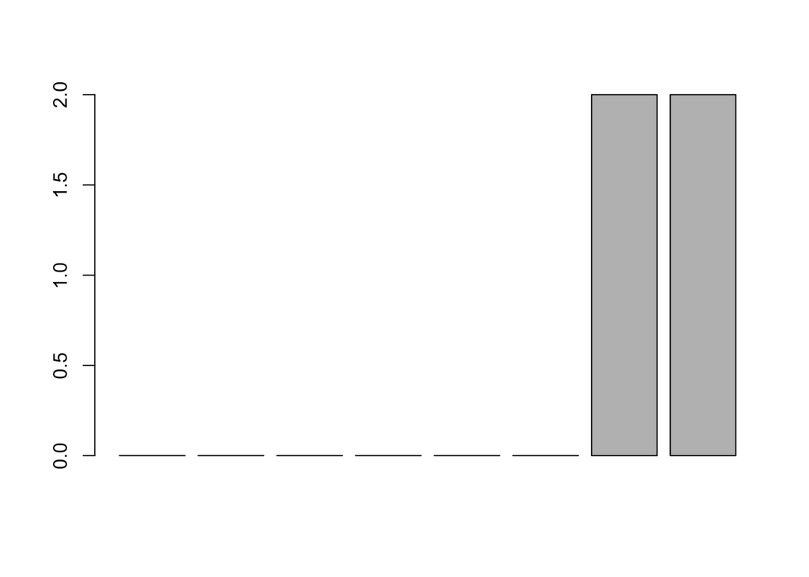

```r
barplot(diag(covs[[2]]))
```

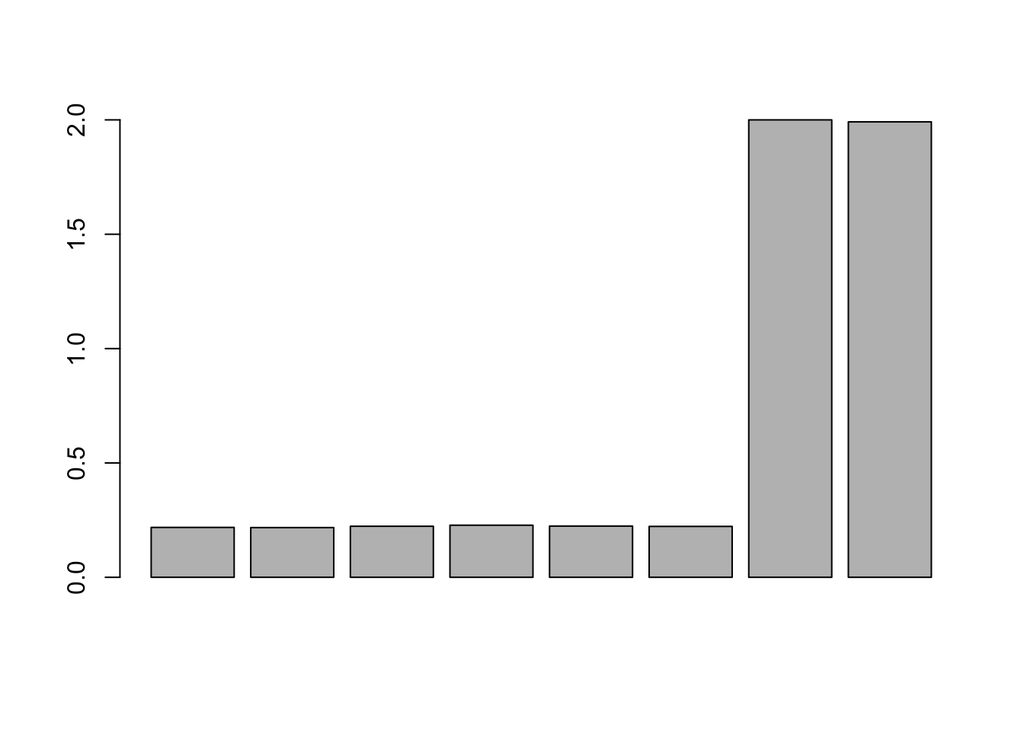

```r
edcov=readRDS("covmatwithoneK.rds")
barplot(diag(edcov[[2]]))
```

```r
w=data.frame(wfull)[,-1]
```

```r
A="withfixedomegamnb"
compute.hm.train.log.lik.pen.with.L(w,se.train = se,covmat = covs,A = A,pen = 1,L = L[-1,])
```

```r
pis=readRDS(paste0("pis",A,".rds"))$pihat

likmat=readRDS(paste0("liketrain",A,".rds"))
test=exp(likmat)
sum(log(test%*%pis))
```

```
## [1] 66556.22
```

```r
for(j in 1:nrow(w)){
total.quant.per.snp.no.baseline(j = j,covmat = covs,b.gp.hat = w,se.gp.hat = se,pis = pis,A = A,checkpoint = F,L = L[-1,])}
```

## Test to show our calculations are accurate:

```r
mash.means=as.matrix(read.table("withfixedomegamnbposterior.means.txt")[,-1])
lfsr.mash=as.matrix(read.table("withfixedomegamnblfsr.txt"))[,-1]
edcov=readRDS("covmatwithfixedomega.rds")
j=10
arrays=post.array.per.snp.no.baseline(j = 10,covmat = edcov,b.gp.hat = w,se.gp.hat = se,L = L[-1,])
k=2

V.gp.hat=diag(se[j,])^2

b.mle = as.vector(w[j,])

LSigL=L[-1,]%*%edcov[[k]]%*%t(L[-1,])
LVL=L[-1,]%*%V.gp.hat%*%t(L[-1,])

LSigL_list=lapply(edcov,function(x){L[-1,]%*%x%*%t(L[-1,])})
identical(LSigL_list[[k]],LSigL)
```

```
## [1] TRUE
```

```r
identical(as.numeric(arrays$post.means[k,]),as.numeric(post.mean.with.proj(b.mle = t(b.mle),tinv = solve(LVL+L[-1,]%*%edcov[[k]]%*%t(L[-1,])),U.k = edcov[[k]],L = L[-1,])))
```

```
## [1] TRUE
```

```r
identical(as.numeric(arrays$post.covs[k,]),as.numeric(diag(post.cov.with.proj(tinv = solve(LVL+L[-1,]%*%edcov[[k]]%*%t(L[-1,])),U.k = edcov[[k]],L = L[-1,]))))
```

```
## [1] TRUE
```

```r
log.lik.snp=log.lik.func(b.mle,LVL,LSigL_list)
log.lik.minus.max=log.lik.snp-max(log.lik.snp)
pis=readRDS("piswithfixedomegamnb.rds")$pihat
exp.vec=exp(log.lik.minus.max)
post.weights=t(exp.vec*pis/sum(exp.vec*pis))

all.equal(as.numeric(post.weights%*%arrays$post.means),as.numeric(mash.means[j,]))
```

```
## [1] TRUE
```

And let’s also do this with the mash framework:

```r
rm(list=ls())
c=readRDS("chatfixedomega.rds")
covl=list();covl[[1]]=c$covmat
t=c$t;b=c$chat;se=c$shat

R=ncol(t)
L=diag(R)-1/R*as.vector(rep(1,R))%*%t(as.vector(rep(1,R)))
wfull=t(L%*%t(b))
sjmat=convertstandarderrors(s.j = se,L=L)##make this be the standard errors of all, it is
```

```r
A="mashtruthwithfixedomega"
covs=readRDS("covmatwithfixedomega.rds")
length(covs)
```

```
## [1] 3
```

```r
compute.hm.train.log.lik.pen(train.b = wfull,se.train = se,covmat = covs,A=A,pen=1)
```

```r
pis=readRDS(paste0("pis",A,".rds"))$pihat


weightedquants=lapply(seq(1:nrow(wfull)),function(j){total.quant.per.snp(j,covs,b.gp.hat=wfull,se.gp.hat = se,pis,A=A,checkpoint = FALSE)})
```

And test to see if calculations are accurate and show that likelihood with MNB is much better than with mash:

```r
cov=readRDS("covmatwithfixedomega.rds")
pis=readRDS(paste0("pis",A,".rds"))$pihat
likmat=readRDS(paste0("liketrain",A,".rds"))
test=exp(likmat)
sum(log(test%*%pis))
```

```
## [1] 59763.34
```

```r
mash.means=as.matrix(read.table("mashtruthwithfixedomegaposterior.means.txt")[,-1])
w=data.frame(wfull)
R=ncol(w)
j=10

arrays=post.array.per.snp.no.baseline(j = 10,covmat = cov,b.gp.hat = w,se.gp.hat = se,L = diag(1,R))
mash.arrays=post.array.per.snp(j = 10,covmat = cov,b.gp.hat = w,se.gp.hat = se)
##show same algebra


k=2

V.gp.hat=diag(se[j,])^2

b.mle = as.vector(w[j,])

lapply(seq(1:5),function(x){all.equal(arrays[[x]],mash.arrays[[x]])})
```

```
## [[1]]
## [1] TRUE
##
## [[2]]
## [1] TRUE
##
## [[3]]
## [1] TRUE
##
## [[4]]
## [1] TRUE
##
## [[5]]
## [1] TRUE
```

```r
L=diag(1,R)
LSigL=L%*%cov[[k]]%*%t(L)
LVL=L%*%V.gp.hat%*%t(L)

LSigL_list=lapply(cov,function(x){L%*%x%*%t(L)})
identical(LSigL_list[[k]],LSigL)
```

```
## [1] TRUE
```

```r
identical(as.numeric(arrays$post.means[k,]),as.numeric(post.mean.with.proj(b.mle = t(b.mle),tinv = solve(LVL+L%*%cov[[k]]%*%t(L)),U.k = cov[[k]],L = L)))
```

```
## [1] TRUE
```

```r
identical(as.numeric(arrays$post.covs[k,]),as.numeric(diag(post.cov.with.proj(tinv = solve(LVL+L%*%cov[[k]]%*%t(L)),U.k = cov[[k]],L = L))))
```

```
## [1] TRUE
```

```r
b.mle=as.vector(t(w[j,]))##turn i into a R x 1 vector
V.gp.hat=diag(se[j,])^2
V.gp.hat.inv <- solve(V.gp.hat)
U.gp1kl= (post.b.gpkl.cov(V.gp.hat.inv, cov[[k]]))

identical(as.numeric(mash.arrays$post.means[k,]),as.numeric(post.b.gpkl.mean(b.mle = b.mle,V.gp.hat.inv = V.gp.hat.inv,U.gp1kl = U.gp1kl)))
```

```
## [1] TRUE
```

```r
identical(as.numeric(mash.arrays$post.covs[k,]),as.numeric(diag(U.gp1kl)))
```

```
## [1] TRUE
```

```r
pis=readRDS("pismashtruthwithfixedomega.rds")$pihat
log.lik.snp=log.lik.func(b.mle,LVL,LSigL_list)
log.lik.minus.max=log.lik.snp-max(log.lik.snp)
exp.vec=exp(log.lik.minus.max)
post.weights=t(exp.vec*pis/sum(exp.vec*pis))

all.equal(as.numeric(post.weights%*%arrays$post.means),as.numeric(mash.means[j,]))
```

```
## [1] TRUE
```

```r
mashnobase.means=as.matrix(read.table("withfixedomegamnbposterior.means.txt")[,-1])

beta=as.matrix(c$beta)
mle=as.matrix(wfull)
mash.means=as.matrix(mash.means)
mashnobaseoneK=as.matrix(read.table("withoneKposterior.means.txt"))[,-1]
standard=sqrt(mean((beta-mle)^2))
sqrt(mean((mash.means-beta)^2))/standard
```

```
## [1] 0.7694544
```

```r
sqrt(mean((mashnobaseoneK-beta)^2))/standard
```

```
## [1] 0.769461
```

```r
sqrt(mean((mashnobase.means-beta)^2))/standard
```

```
## [1] 0.1077839
```

Let’s do the same thing comparing the pis using mash from the truth and from mashnobaseline:

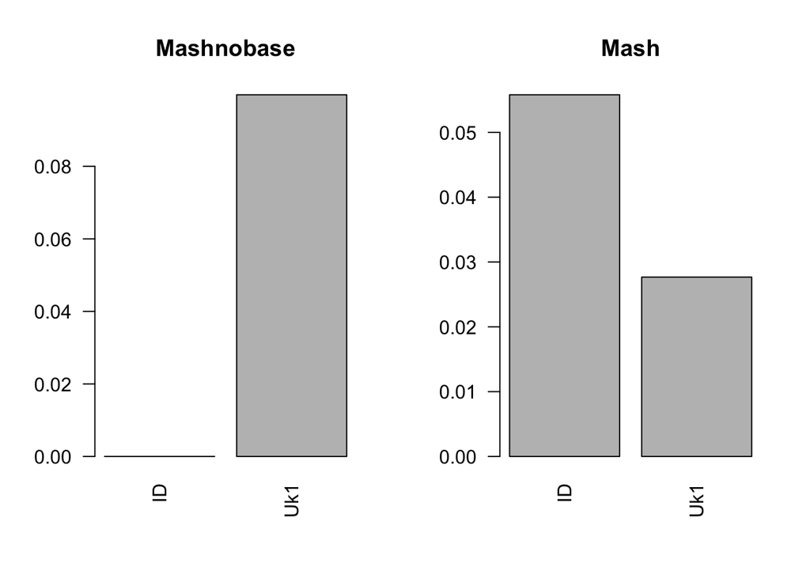

```r
pimash=readRDS("pismashtruthwithfixedomega.rds")$pihat
pied=readRDS("piswithfixedomegamnb.rds")$pihat
piedoneK=readRDS("piswithoneK.rds")$pihat
par(mfrow=c(1,2))
barplot(colSums(matrix(pied[-length(pied)],ncol=2,byrow=TRUE)),names=c("ID","Uk1"),las=2,main="Mashnobase")
barplot(colSums(matrix(pimash[-length(pied)],ncol=2,byrow=TRUE)),names=c("ID","Uk1"),las=2,main="Mash")
```

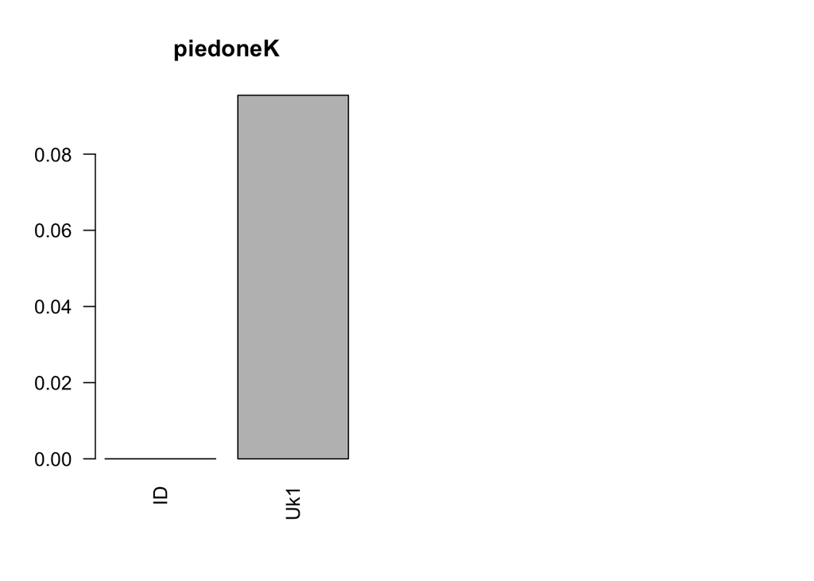

```r
barplot(colSums(matrix(piedoneK[-length(piedoneK)],ncol=2,byrow=TRUE)),names=c("ID","Uk1"),las=2,main="piedoneK")
```

We can see that using the same set of covariance matrices, *mashnobaseline* is better able to emphasize the true configurations because the likelihood and posterior computations incorporate L. Recall, for mash:

$w_{j,R} ~ N(0,V+U)$ $w_{j,R-1} ~ N(0,LVL' + LUL')$ where L is the R-1 x R centering matrix.

In both:

$c = \mu + \beta$ $chat = c + E$ $v \sim \sum_p N(0,Uk)$ $E \sim N(0,V)$

What’s strange is that running mashnobaseline with one learned Uk is really no btter than mash with truth, but much worse than mashnobaseline with the truth.

### And let’s also do this with the mash framework using that one K:

```r
rm(list=ls())
c=readRDS("chatfixedomega.rds")
t=c$t;b=c$chat;se=c$shat

R=ncol(t)
L=diag(R)-1/R*as.vector(rep(1,R))%*%t(as.vector(rep(1,R)))
wfull=t(L%*%t(b))
sjmat=convertstandarderrors(s.j = se,L=L)##make this be the standard errors of all, it is
```

```r
covs=readRDS("covmatwithoneK.rds")
length(covs)
```

```
## [1] 3
```

```r
rm(A)
A="withoneKmash"
compute.hm.train.log.lik.pen(train.b = wfull,se.train = se,covmat = covs,A=A,pen=1)
```

```r
pis=readRDS(paste0("pis",A,".rds"))$pihat


weightedquants=lapply(seq(1:nrow(wfull)),function(j){total.quant.per.snp(j,covs,b.gp.hat=wfull,se.gp.hat = se,pis,A=A,checkpoint = FALSE)})
```

And test to see if calculations are accurate:

```r
cov=readRDS("covmatwithoneK.rds")
mash.means=as.matrix(read.table("withoneKmashposterior.means.txt")[,-1])
w=data.frame(wfull)
R=ncol(w)
j=10

arrays=post.array.per.snp.no.baseline(j = 10,covmat = cov,b.gp.hat = w,se.gp.hat = se,L = diag(1,R))
mash.arrays=post.array.per.snp(j = 10,covmat = cov,b.gp.hat = w,se.gp.hat = se)
##show same algebra


k=2

V.gp.hat=diag(se[j,])^2

b.mle = as.vector(w[j,])

lapply(seq(1:5),function(x){all.equal(arrays[[x]],mash.arrays[[x]])})
```

```
## [[1]]
## [1] TRUE
##
## [[2]]
## [1] TRUE
##
## [[3]]
## [1] TRUE
##
## [[4]]
## [1] TRUE
##
## [[5]]
## [1] TRUE
```

```r
L=diag(1,R)
LSigL=L%*%cov[[k]]%*%t(L)
LVL=L%*%V.gp.hat%*%t(L)

LSigL_list=lapply(cov,function(x){L%*%x%*%t(L)})
identical(LSigL_list[[k]],LSigL)
```

```
## [1] TRUE
```

```r
identical(as.numeric(arrays$post.means[k,]),as.numeric(post.mean.with.proj(b.mle = t(b.mle),tinv = solve(LVL+L%*%cov[[k]]%*%t(L)),U.k = cov[[k]],L = L)))
```

```
## [1] TRUE
```

```r
identical(as.numeric(arrays$post.covs[k,]),as.numeric(diag(post.cov.with.proj(tinv = solve(LVL+L%*%cov[[k]]%*%t(L)),U.k = cov[[k]],L = L))))
```

```
## [1] TRUE
```

```r
b.mle=as.vector(t(w[j,]))##turn i into a R x 1 vector
V.gp.hat=diag(se[j,])^2
V.gp.hat.inv <- solve(V.gp.hat)
U.gp1kl= (post.b.gpkl.cov(V.gp.hat.inv, cov[[k]]))

identical(as.numeric(mash.arrays$post.means[k,]),as.numeric(post.b.gpkl.mean(b.mle = b.mle,V.gp.hat.inv = V.gp.hat.inv,U.gp1kl = U.gp1kl)))
```

```
## [1] TRUE
```

```r
identical(as.numeric(mash.arrays$post.covs[k,]),as.numeric(diag(U.gp1kl)))
```

```
## [1] TRUE
```

```r
beta=as.matrix(c$beta)
mle=as.matrix(wfull)
mashoneK=as.matrix(read.table("withoneKmashposterior.means.txt"))[,-1]
standard=sqrt(mean((beta-mle)^2))
sqrt(mean((mashoneK-beta)^2))/standard
```

```
## [1] 0.769461
```

```r
##let's test mash likelihood###

A="withoneKmash"
pis=readRDS(paste0("pis",A,".rds"))$pihat

likmat=readRDS(paste0("liketrain",A,".rds"))
test=exp(likmat)
sum(log(test%*%pis))
```

```
## [1] 69932.09
```

```r
A="mashtruthwithfixedomega"
pis=readRDS(paste0("pis",A,".rds"))$pihat

likmat=readRDS(paste0("liketrain",A,".rds"))
test=exp(likmat)
sum(log(test%*%pis))
```

```
## [1] 59763.34
```